# Mestrado - dados 2018

Gabriela Galvão

# Título

Efeito da estrutura de paisagem sobre o potencial de recuperação de áreas degradadas

Pacotes necessários

```r
library(vegan)
library(ggplot2)
library(picante)
library(phytools)
library(ape)
library(reshape2)
library(tidyverse)
library(FD)
library(lme4)
library(knitr)
library(rmarkdown)
```

Dados necessários

```r
traits<-read.csv("traits_2018.csv", h=T, ";", row.names = 1)
comunidade <- read.csv("comunidade2018_na_ordem.csv", h=T, ";", row.names=1)
cmm<-comunidade[,20:89]
```

# PERGUNTA 1

Qual a sindrome funcional que prevalece?

# HIPÓTESE 1

H1 As áreas submetidas à restauração possuem uma síndrome funcional da comunidade relacionada a espécies ruderais, com poucas especializações e sementes mais leves

```r
composicao_funcional <- functcomp(x = traits, a = as.matrix(cmm), CWM.type = c("dom"))
paged_table(composicao_funcional)
```

|  | h_max | h_min | leaf_min | leaf_max | semente | dispersal | life_span | type | Floral_rewarning | Pollination_systems | leaf_tipe | filotaxia | nativas |
| --- | --- | --- | --- | --- | --- | --- | --- | --- | --- | --- | --- | --- | --- |
| 3003 | 972.0036 | 361.77102 | 17.193202 | 126.80859 | 1.50358237 | autocoria | annual | erva | Nectar, polen | himenoptera | 0 | alternas | 0 |
| 3008 | 2985.3736 | 1454.48276 | 29.212644 | 163.44828 | 0.22765031 | Anemocoria | annual | arbusto | nectar | aves | 0 | alternas | 0 |
| 3015 | 628.0096 | 165.70192 | 19.022750 | 119.62216 | 0.28141004 | autocoria | annual | erva | polen | wind | 0 | opostas | 0 |
| 3016 | 2272.4799 | 1040.71429 | 25.224265 | 150.55699 | 0.25453022 | Anemocoria | annual | erva | nectar | aves | 0 | alternas | 0 |
| 3017 | 731.7935 | 168.23684 | 19.393407 | 119.72527 | 2.28248830 | autocoria | annual | erva | polen | wind | 0 | verticilada | 0 |
| 3018 | 568.2884 | 140.29308 | 11.459318 | 122.61155 | 0.09935325 | autocoria | annual | erva | polen | wind | 0 | verticilada | 0 |
| 3019 | 841.1321 | 408.49057 | 16.905660 | 92.30189 | 0.25241703 | autocoria | annual | erva | polen | wind | 0 | alternas | 0 |
| 3035 | 4368.0952 | 2177.10623 | 40.146520 | 205.21978 | 0.10828175 | Anemocoria | perennial | arbusto | nectar | aves | 0 | alternas | 1 |
| 3037 | 382.4706 | 100.00000 | 11.517647 | 62.75294 | 0.99739463 | autocoria | annual | erva | Nectar | himenoptera | 0 | oposta | 0 |
| 3049 | 1248.6250 | 578.25000 | 29.700000 | 122.35000 | 0.98295625 | autocoria | annual | erva | polen, nectar | himenoptera | 0 | opostas | 1 |

[output cut: 22 more lines]

# PERGUNTA 2

Como essas sindromes variam em funcao da condincao da paisagem?

# ESCALA DE EFEITO

função multifiti  
Pd: Densidade de manchas de floresta (por/hectare); medida de fragmentação da paisagem.  
NDV: Índice de Vegetação da Diferença Normalizada.

```
## The model including the effect 'ndv800' was the best model according to the specified criterion (AIC, which.min)
```

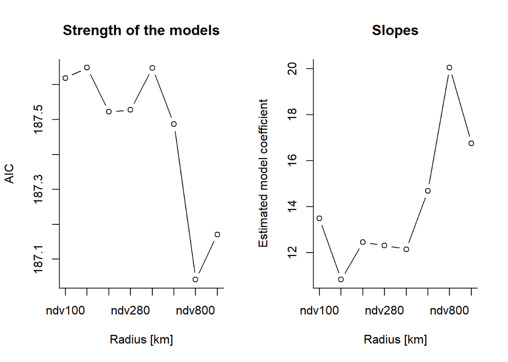

```r
comunidade_multfit <- read.csv("comunidade2018_na_ordem.csv", h=T, ";")
fits_ndv <- multifit(mod="glmer", multief = colnames(comunidade_multfit[4:11]),
                     formula=Riqueza~multief+(1|area), args=c("family=poisson"),data=comunidade_multfit,
                     criterion = "AIC", plot_est = T)
```

```
## The model including the effect 'pd140' was the best model according to the specified criterion (AIC, which.min)
```

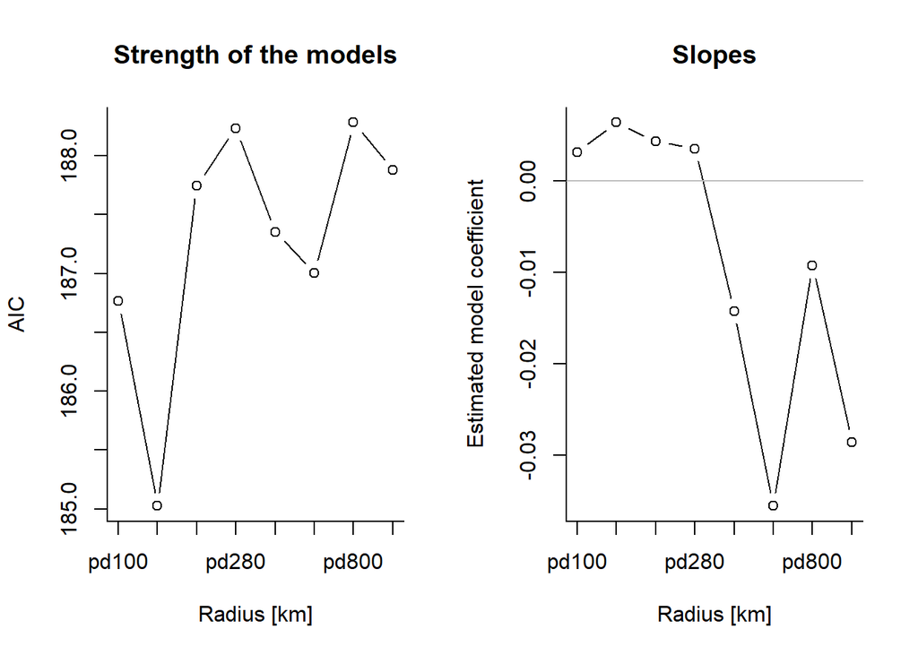

```r
fits_pd <- multifit(mod="glmer", multief = colnames(comunidade_multfit[12:19]),
                    formula=Riqueza~multief+(1|area), args=c("family=poisson"),data=comunidade_multfit,
                    criterion = "AIC", plot_est = T)
```

normalizar e resolver problemas traits

```r
traits$h_max<-log(traits$h_max)
traits$h_min<-log(traits$h_min)
traits$leaf_min<-log(traits$leaf_min)
traits$leaf_max<-log(traits$leaf_max)
traits$semente<- log(traits$semente)
traits$nativas<-as.numeric(traits$nativas)
traits$h_max<-as.numeric(traits$h_max)
traits$h_min<-as.numeric(traits$h_min)
traits$leaf_min<-as.numeric(traits$leaf_min)
traits$leaf_max<-as.numeric(traits$leaf_max)
traits$leaf_tipe<- as.numeric(traits$leaf_tipe)
```

Funcional

```r
div.func <- dbFD(x = traits[,1:5], a = cmm, corr = "lingoes", CWM.type = "all")
```

```
## Species x species distance matrix was not Euclidean. Lingoes correction was applied.
## FRic: Dimensionality reduction was required. The last 62 PCoA axes (out of 68 in total) were removed.
## FRic: Quality of the reduced-space representation (based on corrected distance matrix) = 0.2632042
```

```r
FDis <- div.func$FDis
Feve <- div.func$FEve
RaoQ <- div.func$RaoQ

dados <- cbind(comunidade,FDis, Feve, RaoQ)
```

# HIPÓTESE 2

areas com maior cobertura vegetal possuem maior diversidade funcional, compreendendo uma sindrome funcional de atributos de plantas relacionados a especies mais especialistas.

```r
model1 <- lm(FDis ~ ndv800, data=dados)
summary(model1)
```

```
##
## Call:
## lm(formula = FDis ~ ndv800, data = dados)
##
## Residuals:
##       Min        1Q    Median        3Q       Max
## -0.116398 -0.028929 -0.000366  0.040055  0.098350
##
## Coefficients:
##             Estimate Std. Error t value Pr(>|t|)
## (Intercept)  0.14625    0.01897   7.710 1.33e-08 ***
## ndv800       1.16012    3.20911   0.362     0.72
## ---
## Signif. codes:  0 '***' 0.001 '**' 0.01 '*' 0.05 '.' 0.1 ' ' 1
##
## Residual standard error: 0.0493 on 30 degrees of freedom
## Multiple R-squared:  0.004337,   Adjusted R-squared:  -0.02885
## F-statistic: 0.1307 on 1 and 30 DF,  p-value: 0.7203
```

# HIPÓTESE 3

Áreas com maior densidade de manchas possuem menor diversidade funcional, compreendendo uma síndrome funcional de atributos de plantas relacionados à espécies mais generalistas.

```r
model2 <- lm(FDis ~ pd140, data=dados)
summary(model2)
```

```
##
## Call:
## lm(formula = FDis ~ pd140, data = dados)
##
## Residuals:
##       Min        1Q    Median        3Q       Max
## -0.119523 -0.030634  0.000344  0.036534  0.093684
##
## Coefficients:
##               Estimate Std. Error t value Pr(>|t|)
## (Intercept)  0.1555153  0.0180626   8.610 1.32e-09 ***
## pd140       -0.0001301  0.0006475  -0.201    0.842
## ---
## Signif. codes:  0 '***' 0.001 '**' 0.01 '*' 0.05 '.' 0.1 ' ' 1
##
## Residual standard error: 0.04937 on 30 degrees of freedom
## Multiple R-squared:  0.001345,   Adjusted R-squared:  -0.03194
## F-statistic: 0.04039 on 1 and 30 DF,  p-value: 0.8421
```

Diversidade Filogenética

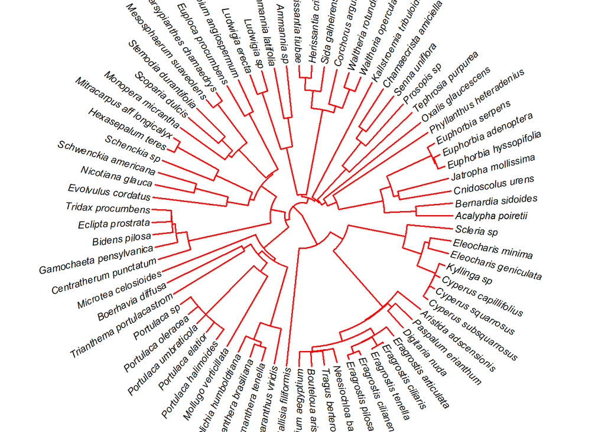

```r
tree <- read.tree("tree2018.tre")
plot(tree, type="fan", show.tip.label = TRUE,
            show.node.label = F, edge.color = "red", edge.width = 1.5,
            tip.color = "black", cex = 0.7, label.offset = 2, no.margin = T)
```

checar nomes

```r
cmm_p <- comunidade[,1:19]
setdiff(colnames(cmm), tree$tip.label)
```

```
## character(0)
```

Áreas (unidade amostral) nas linhas e espécies nas colunas (variável resposta).

```r
comunidade<- read.csv("comunidade2018_na_ordem.csv", h=T, ";", row.names=1)
comunidade_especies <- comunidade[,20:89]
```

Áreas (unidade amostral) nas linhas + métricas de paisagem nas coluna (variável preditoras: pd, ndvi) + tipo de intervencao.

```r
comunidade_preditoras <- comunidade[,1:19]
```

MPD  
quantificar a distância média do parentesco entre 2 espécies em uma comunidade.

```r
MPD <- mpd(comunidade_especies, cophenetic(tree),
           abundance.weighted = TRUE)
MPD<- as.data.frame(MPD)
rownames(MPD) <- rownames(comunidade)
```

MNTD  
quantificar a média de VALORES MÍNIMOS de parentesco entre 2 espécies em uma comunidade. qual o valor médio da distância para o vizinho mais próximo.

```r
MNTD <- mntd(comunidade_especies, cophenetic(tree),
             abundance.weighted = TRUE)
MNTD<- as.data.frame(MNTD)
rownames(MNTD) <- rownames(comunidade)
```

espécies terminais sao mais aparentadas na area 3018 e menos aparentadas no controle; (maior div. filo no controle como esperado(?))

```r
metricas_divergencia <- data.frame(MPD = MPD,
                                   MNTD = MNTD)
metricas_divergencia <- cbind(metricas_divergencia, comunidade_preditoras)
```

# HIPÓTESE 4

Áreas com maior cobertura vegetal possuem maior diversidade filogenética no banco de sementes.

# HIPÓTESE 5

Áreas com maior densidade de manchas possuem menor diversidade filogenética no banco de sementes.

MPD PLOT

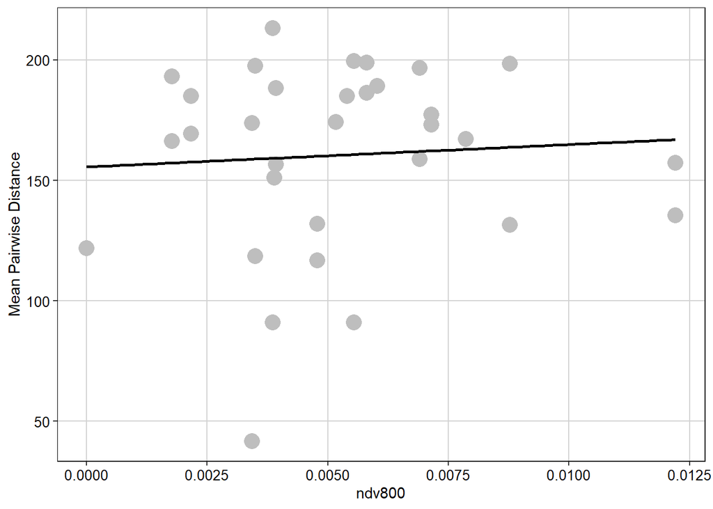

```r
MPD_plot_ndv <- ggplot(metricas_divergencia, aes(ndv800, MPD)) +
  labs(x = "ndv800",
       y = "Mean Pairwise Distance") +
  geom_point(size = 5, shape = 19, col = "gray") + tema_grafico+geom_smooth(method = lm, se = FALSE, color = "black")
MPD_plot_ndv
```

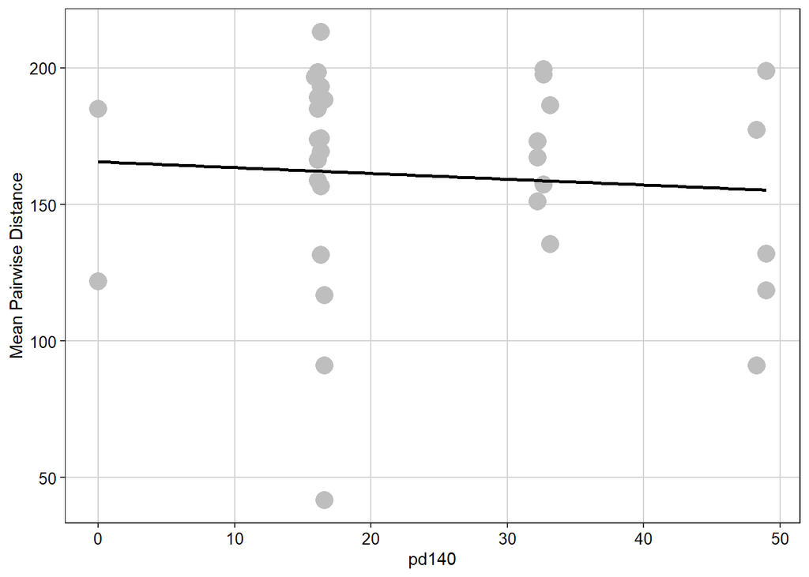

```r
MPD_plot_pd <- ggplot(metricas_divergencia, aes(pd140, MPD)) +
  labs(x = "pd140",
       y = "Mean Pairwise Distance") +
  geom_point(size = 5, shape = 19, col = "gray") + tema_grafico+ geom_smooth(method = lm, se = FALSE, color = "black")
MPD_plot_pd
```

MNTD PLOT

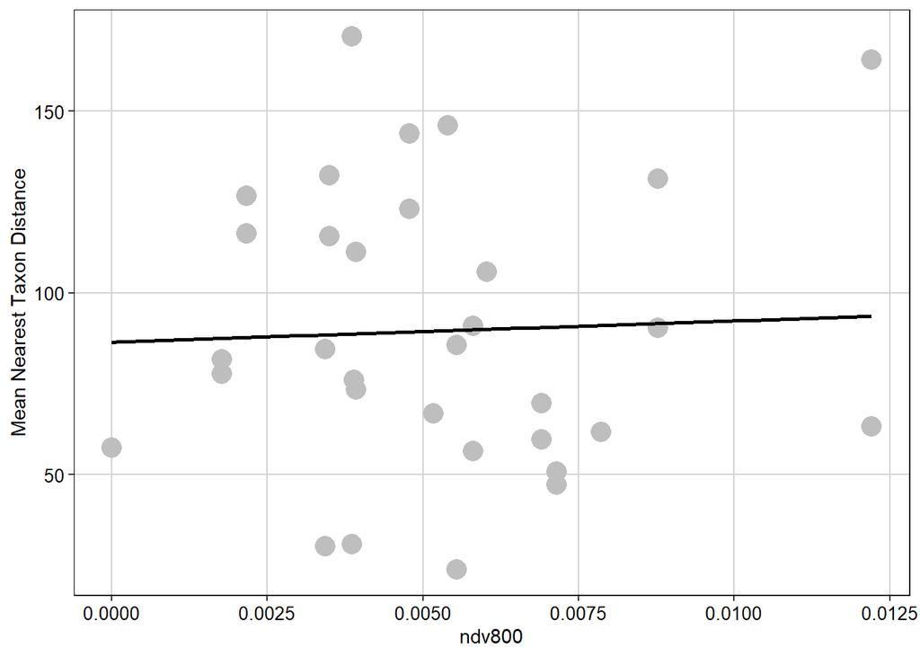

```r
MNTD_plot_ndv <- ggplot(metricas_divergencia, aes(ndv800, MNTD)) +
  labs(x = "ndv800",
       y = "Mean Nearest Taxon Distance",
       size = 8)+
  geom_point(size = 5, shape = 19, col = "gray") +
  tema_grafico +
  geom_smooth(method = lm, se = FALSE, color = "black")
MNTD_plot_ndv
```

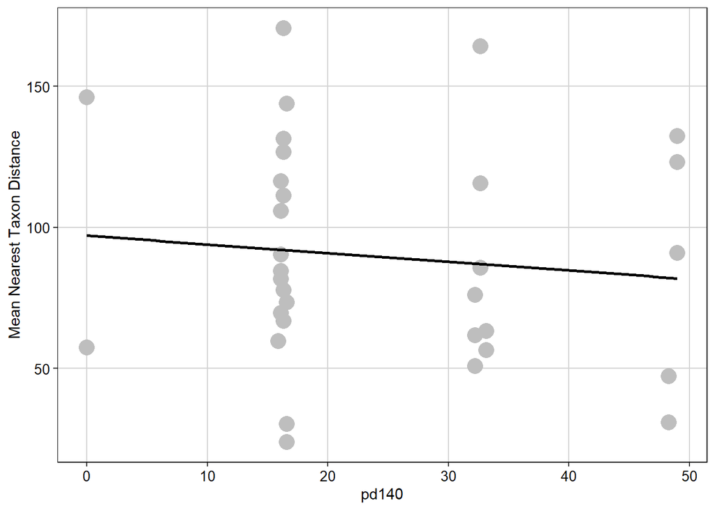

```r
MNTD_plot_pd <- ggplot(metricas_divergencia, aes(pd140, MNTD)) +
  labs(x = "pd140",
       y = "Mean Nearest Taxon Distance",
       size = 8)+
  geom_point(size = 5, shape = 19, col = "gray") +
  tema_grafico +
  geom_smooth(method = lm, se = FALSE, color = "black")
MNTD_plot_pd
```

# REPETIR TUDO SEM ESPÉCIES EXÓTICAS

Dados sem exótica

```r
traits_SE<-read.csv("traits_2018_sem_exotica.csv", h=T, ";", row.names = 1)
comunidade_SE <- read.csv("comunidade2018_sem_exotica.csv", h=T, ";", row.names=1)
cmm_SE<-comunidade_SE[,20:75]
```

## PERGUNTA 1

Qual a sindrome funcional que prevalece?

```r
composicao_funcional_SE <- functcomp(x = traits_SE, a = as.matrix(cmm_SE), CWM.type = c("dom"))
paged_table(composicao_funcional_SE)
```

|  | h_max | h_min | leaf_min | leaf_max | semente | dispersal | life_span | type | Floral_rewarning | Pollination_systems | leaf_tipe | filotaxia | nativas |
| --- | --- | --- | --- | --- | --- | --- | --- | --- | --- | --- | --- | --- | --- |
| 3003 | 550.1147 | 124.83945 | 11.561927 | 92.05505 | 1.86895996 | autocoria | annual | erva | Nectar, polen | himenoptera | 0 | opostas | 0 |
| 3008 | 515.8152 | 185.65217 | 12.076087 | 95.56522 | 0.31317776 | autocoria | annual | erva | polen | himenoptera, diptera | 0 | verticilada | 0 |
| 3015 | 625.8999 | 140.79857 | 16.175309 | 87.26914 | 0.27848205 | autocoria | annual | erva | polen | himenoptera | 0 | opostas | 0 |
| 3016 | 433.8856 | 105.52786 | 10.592375 | 91.82698 | 0.42222058 | autocoria | annual | erva | Nectar, polen | himenoptera | 0 | verticilada | 0 |
| 3017 | 703.8599 | 157.06745 | 16.361045 | 113.77910 | 2.49310753 | autocoria | annual | erva | polen | wind | 0 | verticilada | 0 |
| 3018 | 546.4058 | 156.66134 | 11.584665 | 128.67412 | 0.11745163 | autocoria | annual | erva | polen | lepdoptera | 0 | verticilada | 0 |
| 3019 | 303.7500 | 138.54167 | 13.458333 | 75.87500 | 0.27412713 | autocoria | annual | erva | polen | wind | 0 | opostas | 0 |
| 3035 | 282.7632 | 117.76316 | 15.131579 | 89.14474 | 0.26816996 | autocoria | annual | erva | polen | lepdoptera | 0 | alternas | 0 |
| 3037 | 382.4706 | 100.00000 | 11.517647 | 62.75294 | 0.99739463 | autocoria | annual | erva | Nectar | himenoptera | 0 | oposta | 0 |
| 3049 | 442.7778 | 104.72222 | 17.388889 | 128.27778 | 1.64243055 | autocoria | annual | erva | polen | lepdoptera | 0 | verticilada | 0 |

[output cut: 22 more lines]

## PERGUNTA 2

Como essas sindromes variam em funcao da condincao da paisagem?

função multifiti  
Pd: Densidade de manchas de floresta (por/hectare); medida de fragmentação da paisagem.  
NDV: Índice de Vegetação da Diferença Normalizada.

```
## The model including the effect 'ndv800' was the best model according to the specified criterion (AIC, which.min)
```

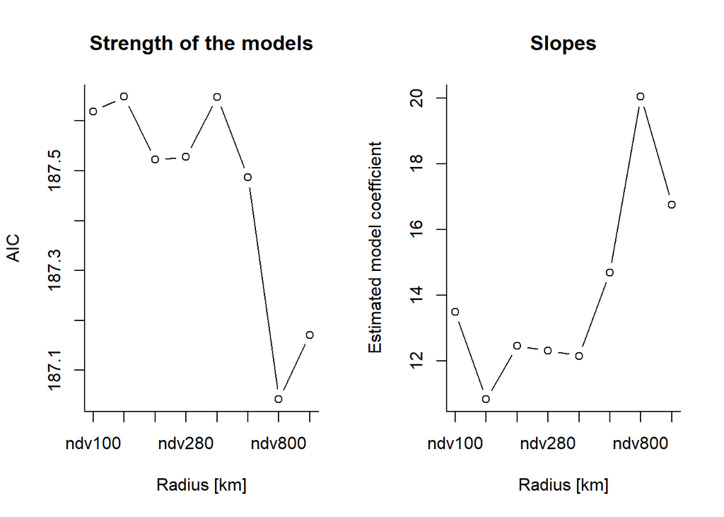

```r
comunidade_multfit_SE <- read.csv("comunidade2018_sem_exotica.csv", h=T, ";")
fits_ndv_SE <- multifit(mod="glmer", multief = colnames(comunidade_multfit_SE[4:11]),
                     formula=Riqueza~multief+(1|area), args=c("family=poisson"),data=comunidade_multfit_SE,
                     criterion = "AIC", plot_est = T)
```

```
## The model including the effect 'pd140' was the best model according to the specified criterion (AIC, which.min)
```

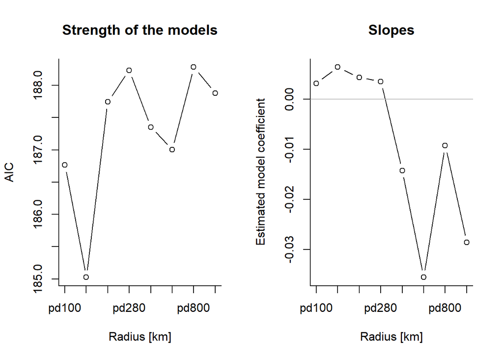

```r
fits_pd_SE <- multifit(mod="glmer", multief = colnames(comunidade_multfit_SE[12:19]),
                    formula=Riqueza~multief+(1|area), args=c("family=poisson"),data=comunidade_multfit_SE,
                    criterion = "AIC", plot_est = T)
```

funcional

```r
div.func_SE <- dbFD(x = traits_SE[,1:5], a = cmm_SE, corr = "lingoes", CWM.type = "all")
```

```
## Species x species distance matrix was not Euclidean. Lingoes correction was applied.
## FRic: Dimensionality reduction was required. The last 50 PCoA axes (out of 54 in total) were removed.
## FRic: Quality of the reduced-space representation (based on corrected distance matrix) = 0.2335698
```

## HIPÓTESE 2

areas com maior cobertura vegetal possuem maior diversidade funcional, compreendendo uma sindrome funcional de atributos de plantas relacionados a especies mais especialistas.

```r
model1_SE <- lm(FDis_SE ~ ndv800, data=dados_SE)
summary(model1_SE)
```

```
##
## Call:
## lm(formula = FDis_SE ~ ndv800, data = dados_SE)
##
## Residuals:
##       Min        1Q    Median        3Q       Max
## -0.095002 -0.020105  0.007564  0.019715  0.062515
##
## Coefficients:
##             Estimate Std. Error t value Pr(>|t|)
## (Intercept)  0.13053    0.01249  10.449 1.63e-11 ***
## ndv800      -1.02999    2.11328  -0.487     0.63
## ---
## Signif. codes:  0 '***' 0.001 '**' 0.01 '*' 0.05 '.' 0.1 ' ' 1
##
## Residual standard error: 0.03247 on 30 degrees of freedom
## Multiple R-squared:  0.007856,   Adjusted R-squared:  -0.02522
## F-statistic: 0.2375 on 1 and 30 DF,  p-value: 0.6295
```

## HIPÓTESE 3

Áreas com maior densidade de manchas possuem menor diversidade funcional, compreendendo uma síndrome funcional de atributos de plantas relacionados à espécies mais generalistas.

```r
model2_SE <- lm(FDis_SE ~ pd140, data=dados_SE)
summary(model2_SE)
```

```
##
## Call:
## lm(formula = FDis_SE ~ pd140, data = dados_SE)
##
## Residuals:
##       Min        1Q    Median        3Q       Max
## -0.097962 -0.013766  0.005033  0.019758  0.060717
##
## Coefficients:
##               Estimate Std. Error t value Pr(>|t|)
## (Intercept)  0.1401637  0.0115037  12.184 3.81e-13 ***
## pd140       -0.0006160  0.0004124  -1.494    0.146
## ---
## Signif. codes:  0 '***' 0.001 '**' 0.01 '*' 0.05 '.' 0.1 ' ' 1
##
## Residual standard error: 0.03144 on 30 degrees of freedom
## Multiple R-squared:  0.06922,    Adjusted R-squared:  0.0382
## F-statistic: 2.231 on 1 and 30 DF,  p-value: 0.1457
```

Diversidade Filogenética

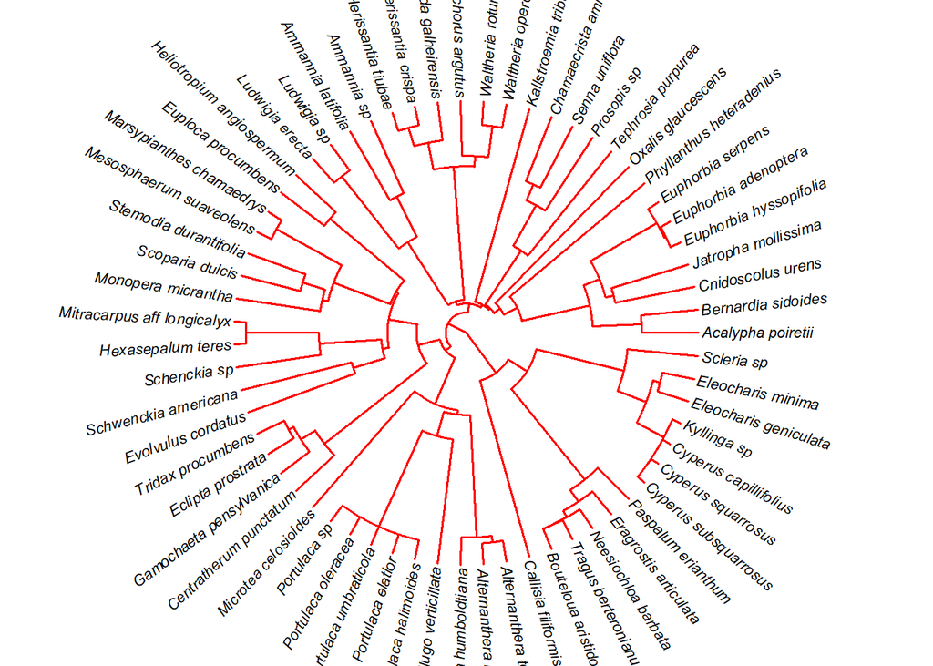

```r
tree <- read.tree("tree2018.tre")
tree_SE <- drop.tip(tree, c("Nicotiana_glauca", "Tridax_procumbens
", "Bidens_pilosa", "Boerhavia_diffusa", "Trianthema_portulacastrom", "
Portulaca_oleracea", "Amaranthus_viridis", "Dactyloctenium_aegyptium", "Eragrostis_pilosa", "Eragrostis_cilianensis", "Eragrostis_tenella", "Eragrostis_ciliaris", "Digitaria_nuda", "Aristida_adscensionis"))

plot(tree_SE, type="fan", show.tip.label = TRUE,
            show.node.label = F, edge.color = "red", edge.width = 1.5,
            tip.color = "black", cex = 0.7, label.offset = 2, no.margin = T)
```

checar nomes

```r
cmm_p <- comunidade_SE[,1:19]
setdiff(colnames(cmm_SE), tree_SE$tip.label)
```

```
## character(0)
```

Áreas (unidade amostral) nas linhas e espécies nas colunas (variável resposta).

```r
comunidade_SE<- read.csv("comunidade2018_sem_exotica.csv", h=T, ";", row.names=1)
names(comunidade_SE)
```

```
##  [1] "area_ha"                    "metodo"
##  [3] "ndv100"                     "ndv140"
##  [5] "ndv200"                     "ndv280"
##  [7] "ndv400"                     "ndv560"
##  [9] "ndv800"                     "ndv1130"
## [11] "pd100"                      "pd140"
## [13] "pd200"                      "pd280"
## [15] "pd400"                      "pd560"
## [17] "pd800"                      "pd1130"
## [19] "mod"                        "Acalypha_poiretii"
## [21] "Bernardia_sidoides"         "Cnidoscolus_urens"
## [23] "Jatropha_mollissima"        "Euphorbia_hyssopifolia"
## [25] "Euphorbia_adenoptera"       "Euphorbia_serpens"
## [27] "Phyllanthus_heteradenius"   "Oxalis_glaucescens"
## [29] "Tephrosia_purpurea"         "Senna_uniflora"
```

[output cut: 23 more lines]

```r
comunidade_especies_SE <- comunidade_SE[,20:75]
```

Áreas (unidade amostral) nas linhas + métricas de paisagem nas coluna (variável preditoras: pd, ndvi) + tipo de intervencao.

```r
comunidade_preditoras_SE <- comunidade_SE[,1:19]
```

MPD  
quantificar a distância média do parentesco entre 2 espécies em uma comunidade.

```r
MPD_SE <- mpd(comunidade_especies_SE, cophenetic(tree_SE),
           abundance.weighted = TRUE)
MPD_SE<- as.data.frame(MPD_SE)
rownames(MPD_SE) <- rownames(comunidade_SE)
MPD_SE
```

```
##             MPD_SE
## 3003     146.47445
## 3008     182.71793
## 3015     180.27582
## 3016     191.12922
## 3017     167.39522
## 3018     106.89232
## 3019     189.37229
## 3035     145.54484
## 3037     197.62496
## 3049     188.34267
## 3054     165.65290
## 3088     162.71519
## 4097     183.24202
## 4142     166.60421
## 4147     202.37626
## 4150     154.14093
## 4153     155.11455
## 4160     170.26757
## 4173     172.31698
## 4178     146.17030
## 4179     158.60912
## 4185     149.88243
## 4196     187.44428
## CAPTACAO  82.28613
## controle 201.22574
## junco    112.66907
## pousio1   39.05520
## pousio2  166.39516
## pousio3  177.94063
## pousio4  149.89016
## SALAO    208.07437
## uri      204.15991
```

MNTD  
quantificar a média de VALORES MÍNIMOS de parentesco entre 2 espécies em uma comunidade. qual o valor médio da distância para o vizinho mais próximo.

```r
MNTD_SE <- mntd(comunidade_especies_SE, cophenetic(tree_SE),
             abundance.weighted = TRUE)
MNTD_SE<- as.data.frame(MNTD_SE)
rownames(MNTD_SE) <- rownames(comunidade_SE)
MNTD_SE
```

```
##            MNTD_SE
## 3003      79.19509
## 3008      65.86879
## 3015      76.60136
## 3016      85.86391
## 3017      73.74453
## 3018      34.28502
## 3019      69.51104
## 3035      34.06042
## 3037     115.58048
## 3049      81.98834
## 3054      85.97771
## 3088      42.51832
## 4097      99.30225
## 4142      33.23880
## 4147      76.83236
## 4150      53.07034
## 4153      89.38190
## 4160      62.67385
## 4173      41.10015
## 4178      42.23698
## 4179      40.43992
## 4185     128.25702
## 4196     108.36855
## CAPTACAO  28.03106
## controle 246.71880
## junco     32.65479
## pousio1   29.95242
## pousio2   81.69597
## pousio3   66.12381
## pousio4  200.38421
## SALAO    102.61363
## uri       89.16630
```

```r
metricas_divergencia_SE <- data.frame(MPD_SE = MPD_SE,
                                   MNTD_SE = MNTD_SE)
metricas_divergencia_SE <- cbind(metricas_divergencia_SE, comunidade_preditoras_SE)
```

## HIPÓTESE 4

Áreas com maior cobertura vegetal possuem maior diversidade filogenética no banco de sementes.

## HIPÓTESE 5

Áreas com maior densidade de manchas possuem menor diversidade filogenética no banco de sementes.

MPD PLOT

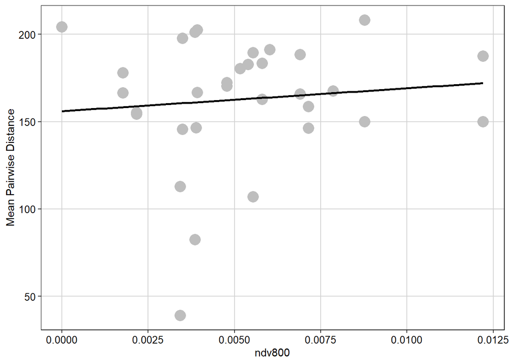

```r
MPD_plot_ndv_SE <- ggplot(metricas_divergencia_SE, aes(ndv800, MPD_SE)) +
  labs(x = "ndv800",
       y = "Mean Pairwise Distance") +
  geom_point(size = 5, shape = 19, col = "gray") + tema_grafico+geom_smooth(method = lm, se = FALSE, color = "black")
MPD_plot_ndv_SE
```

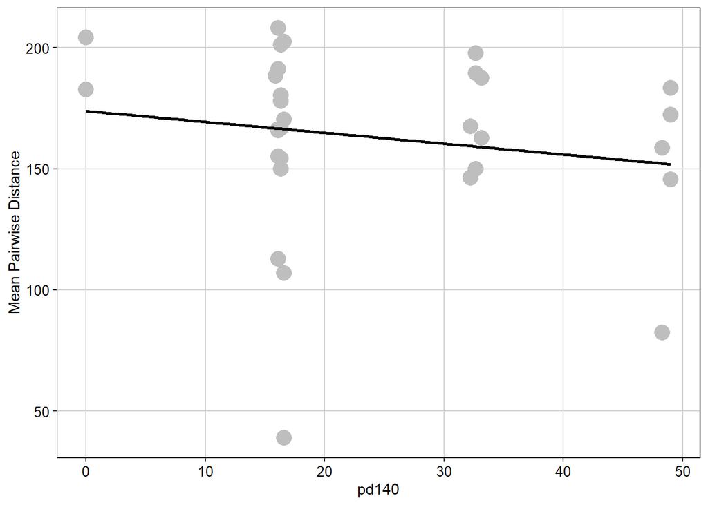

```r
MPD_plot_pd_SE <- ggplot(metricas_divergencia_SE, aes(pd140, MPD_SE)) +
  labs(x = "pd140",
       y = "Mean Pairwise Distance") +
  geom_point(size = 5, shape = 19, col = "gray") + tema_grafico+ geom_smooth(method = lm, se = FALSE, color = "black")
MPD_plot_pd_SE
```

MNTD PLOT

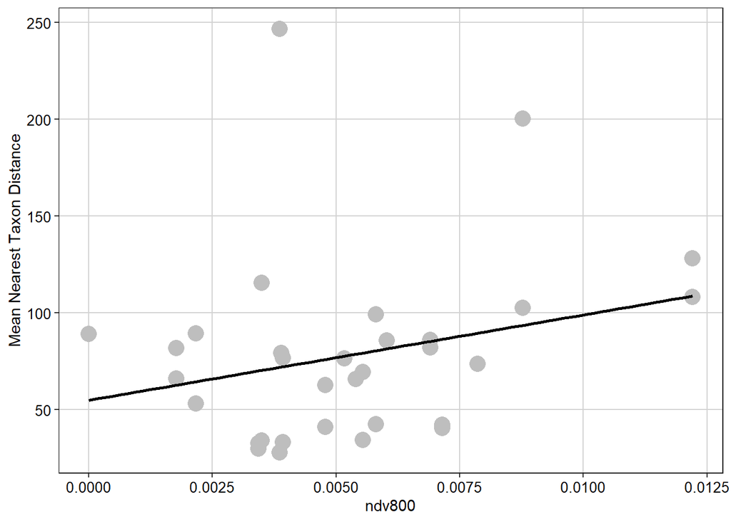

```r
MNTD_plot_ndv_SE <- ggplot(metricas_divergencia_SE, aes(ndv800, MNTD_SE)) +
  labs(x = "ndv800",
       y = "Mean Nearest Taxon Distance",
       size = 8)+
  geom_point(size = 5, shape = 19, col = "gray") +
  tema_grafico +
  geom_smooth(method = lm, se = FALSE, color = "black")
MNTD_plot_ndv_SE
```

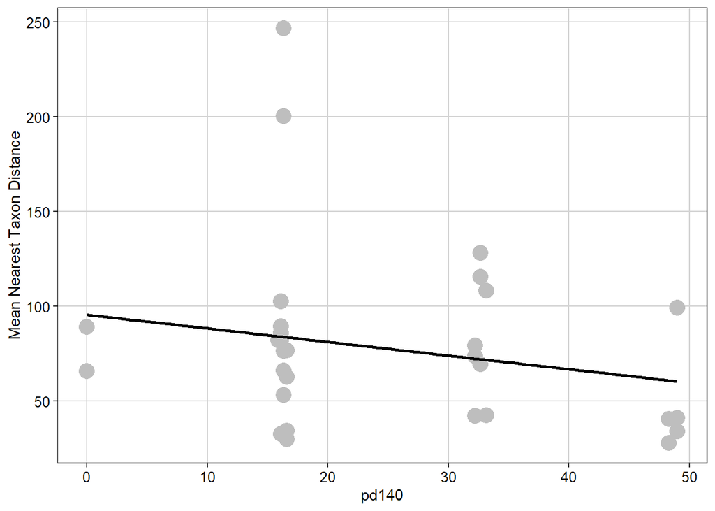

```r
MNTD_plot_pd_SE <- ggplot(metricas_divergencia_SE, aes(pd140, MNTD_SE)) +
  labs(x = "pd140",
       y = "Mean Nearest Taxon Distance",
       size = 8)+
  geom_point(size = 5, shape = 19, col = "gray") +
  tema_grafico +
  geom_smooth(method = lm, se = FALSE, color = "black")
MNTD_plot_pd_SE
```